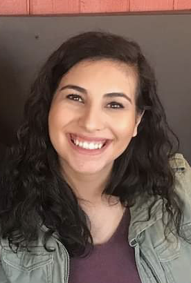

# Christina Como

## Bio

Christina Como studies the signaling mechanisms allowing for the specification of specialized meningeal fibroblasts and the signals generated from specialized meningeal fibroblasts to allow for proper neurogenesis and brain development. By knocking out the transcription factor FOXC1, a protein only made by meningeal fibroblasts and not by any neural cells, I can disrupt meninges formation that leads to significant central nervous system defects. To elucidate this cellular crosstalk, I use advanced bioinformatic and molecular analyses. Using the cutting-edge technology, spatial transcriptomics, I have identified several key developmental processes that are aberrant in the meninges and in the developing brain. Currently I am using electroporation to rescue these signaling mechanisms to rescue brain development, neurogenesis, neural migration, and cell cycle exit in basal apical progenitors.

## Education

**University of Colorado Anschutz Medical Campus** | Aurora, CO

Ph.D. in Neuroscience | July 2019 - present

**Certified Associates in Project Management (CAPM)**

April 2022 – April 2025

**Coe College** | Cedar Rapids, IA

B.A. in Molecular Biology | September 2012 - May 2016

## Experience

**University of Colorado** | Research Assistant | August 2016 - August 2019

## Publications

1. Como CN, Kim S, Siegenthaler J. “Stuck on you: Meninges cellular crosstalk in development.” Current Opinion in Neurobiology. 2023 Feb 9; 79:102676.
2. Como CN, Cervantes C, Pawlikowski B, Siegenthaler J. “Retinoic acid signaling in mouse retina endothelial cells is required for early angiogenic growth.” Differentiation. 2023 Mar-Apr; 130:16-27.
3. Derk J, Como CN, Jones HE, Joyce LR, Bonney S, O’Rourke R, Pawlikowski B, Doran K, Siegenthaler JA. “Formation and function of the meninges arachnoid barrier around the developing brain.” Developmental Cell. 2023 June; 06.10.495709.
4. Bubak AN, Como CN, Hassell JE Jr, Mescher T, Frietze SE, Niemeyer CS, Cohrs RJ, Nagel MA. “Targeted RNA Sequencing of VZV-Infected Brain Vascular Adventitial Fibroblasts Indicates That Amyloid May Be Involved in VZV Vasculopathy.” Neurology Neuroimmunology and Neuroinflammation. 2021 Jan; 10;9(1):e1103.
5. Como CN, Jones HE, Siegenthaler J. “Not just a ‘drain’: venules sprout brain capillaries.” Trends in Neurosciences. 2021. Nov;44(11):849-851.
6. Derk J, Jones HE, Como CN, Pawlikowski B, Siegenthaler JA. “Living on the Edge of the CNS: Meninges Cell Diversity in Health and Disease.” Frontiers in Cellular Neuroscience. 2021; 15:761506.
7. Bubak AN, Mescher T, Mariani M, Frietze SE, Hassell JE Jr, Niemeyer CS, Como CN, Burnet AM, Subramanian PS, Cohrs RJ, Mahalingam R, Nagel MA. “Targeted RNA Sequencing of Formalin-Fixed, Paraffin-Embedded Temporal Arteries From Giant Cell Arteritis Cases Reveals Viral Signatures.” Neurology Neuroimmunology and Neuroinflammation. 2021 Nov;8(6).
8. Bubak AN, Beseler C, Como CN, Coughlan CM, Johnson NR, Hassell JE, Burnet AM, Mescher T, Schmid DS, Coleman C, Mahalingam R, Cohrs RJ, Boyd TD, Potter H, Shilleh AH, Russ HA, Nagel MA. “Amylin, Aβ42, and Amyloid in Varicella Zoster Virus Vasculopathy Cerebrospinal Fluid and Infected Vascular Cells.” Journal of Infectious Disease. 2021 Apr 8;223(7):1284-1294.
9. Bubak AN, Traina-Dorge V, Como CN, Feia B, Pearce CM, Doyle-Meyers L, Das A, Looper J, Mahalingam R, Nagel MA. “Elevated serum substance P during simian varicella virus infection in rhesus macaques: implications for chronic inflammation and adverse cerebrovascular events.” Journal of Neurovirology. 2020 Dec;26(6):945-951.
10. Bubak AN, Beseler C, Como CN, Tyring SK, Haley C, Mescher T, Hassell JE Jr, Cohrs RJ, Potter H, Nagel MA. “Acute zoster plasma contains elevated amyloid, correlating with Aβ42 and amylin levels, and is amyloidogenic.” Journal of Neurovirology. 2020 Jun;26(3):422-428.
11. Bubak AN, Como CN, Coughlan CM, Johnson NR, Hassell JE, Mescher T, Niemeyer CS, Mahalingam R, Cohrs RJ, Boyd TD, Potter H, Russ HA, Nagel MA. “Varicella-Zoster Virus Infection of Primary Human Spinal Astrocytes Produces Intracellular Amylin, Amyloid-β, and an Amyloidogenic Extracellular Environment.” Journal of Infectious Disease. 2020 Mar 16;221(7):1088-1097.
12. Como CN, Bubak AN, Blackmon AM, Jones D, Mueller NH, Davidson R, Nagel MA. “Varicella Zoster Virus Induces Differential Cell-Type Specific Responses in Human Corneal Epithelial Cells and Keratocytes.” Investigations in Ophthalmology Visual Sciences. 2019 Feb 1;60(2):704-711.
13. Blackmon AM, Como CN, Bubak AN, Mescher T, Jones D, Nagel MA. “Varicella Zoster Virus Alters Expression of Cell Adhesion Proteins in Human Perineurial Cells via Interleukin 6.” Journal of Infectious Disease. 2019 Sep 26;220(9):1453-1461. doi: 10.1093/infdis/jiz095.
14. Jones D, Como CN, Jing L, Blackmon A, Neff CP, Krueger O, Bubak AN, Palmer BE, Koelle DM, Nagel MA. “Varicella zoster virus productively infects human peripheral blood mononuclear cells to modulate expression of immunoinhibitory proteins and blocking PD-L1 enhances virus-specific CD8+ T cell effector function.” PLoS Pathogens. 2019 Mar;15(3):e1007650.
15. Como CN, Pearce CM, Cohrs RJ, Baird NL. “Interleukin-6 and type 1 interferons inhibit varicella zoster virus replication in human neurons.” Virology. 2018 Sep;522:13-18.
16. Bubak AN, Como CN, Blackmon AM, Frietze S, Mescher T, Jones D, Cohrs RJ, Paucek P, Baird NL, Nagel MA. “Varicella Zoster Virus Induces Nuclear Translocation of the Neurokinin-1 Receptor, Promoting Lamellipodia Formation and Viral Spread in Spinal Astrocytes.” Journal of Infectious Disease. 2018 Sep 8;218(8):1324-1335.
17. Bubak AN, Como CN, Blackmon AM, Jones D, Nagel MA. “Varicella zoster virus differentially alters morphology and suppresses proinflammatory cytokines in primary human spinal cord and hippocampal astrocytes.” Journal of Neuroinflammation. 2018 Nov 15;15(1):318.
18. Cohrs RJ, Lee KS, Beach A, Sanford B, Baird NL, Como CN, Graybill C, Jones D, Tekeste E, Ballard M, Chen X, Yalacki D, Frietze S, Jones K, Lenac Rovis T, Jonjić S, Haas J, Gilden D. “Targeted Genome Sequencing Reveals Varicella-Zoster Virus Open Reading Frame 12 Deletion.” Journal of Virology. 2017 Oct 15;91(20).